# IBM HR Analytics Employee Attrition & Performance

Wesley Gardiner

11/18/2020

# Introduction

Today I will be using the IBM HR Analytics Employee Attrition & Performance data set from Kaggle found :[here](https://www.kaggle.com/pavansubhasht/ibm-hr-analytics-attrition-dataset)

# EDA - Steps to understand our data

I think its wise to first get an understanding of our data through different graphs of variables.

## Age Distribution

### Does age affect attrition?

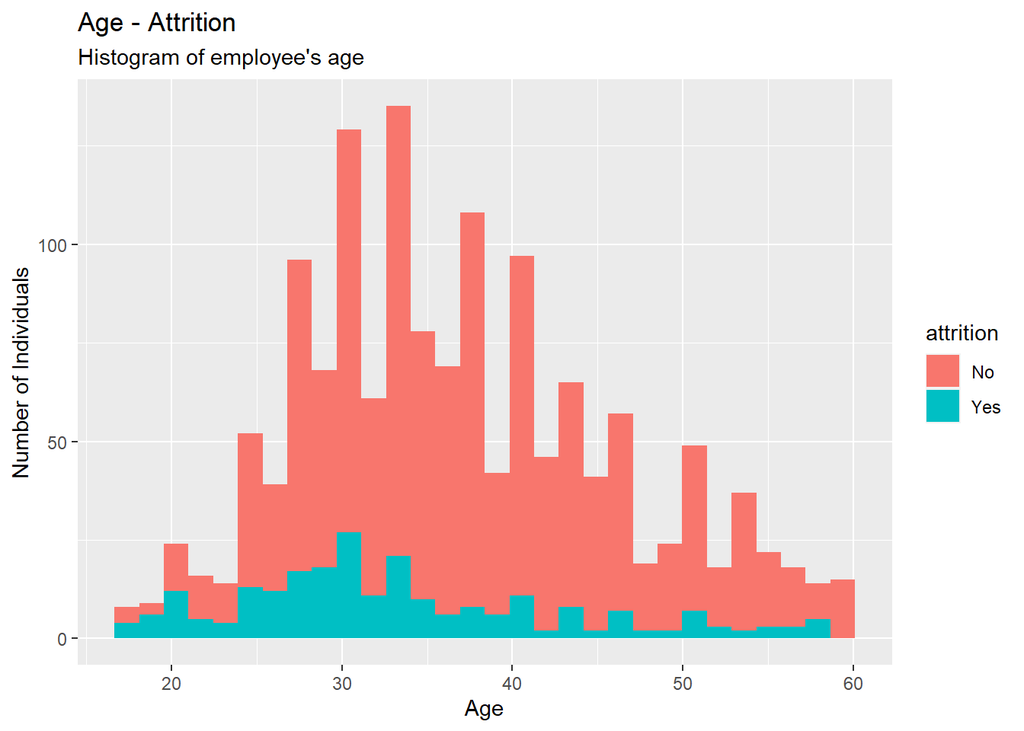

```r
kaggle_data %>%
  ggplot(aes(x = age, fill = attrition)) +
  geom_histogram() +
  labs(
    title = "Age - Attrition",
    subtitle = "Histogram of employee's age",
    y = "Number of Individuals",
    x = "Age"
  )
```

### Departmental Attrition?

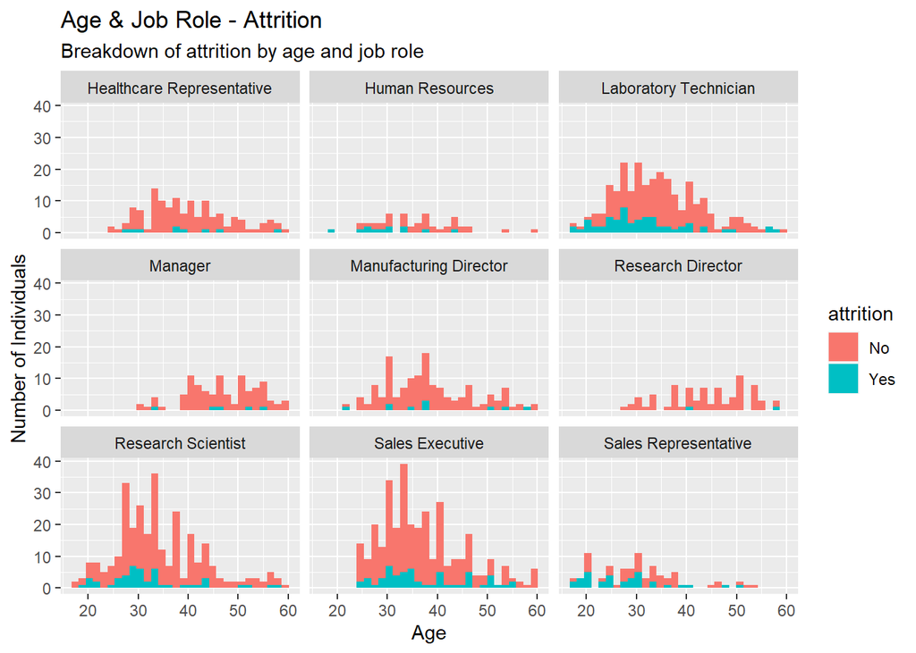

```r
kaggle_data %>%
  ggplot(aes(x = age, fill = attrition)) +
  geom_histogram() +
  facet_wrap(~job_role)+
  labs(
    title = "Age & Job Role - Attrition",
    subtitle = "Breakdown of attrition by age and job role",
    y = "Number of Individuals",
    x = "Age"
  )
```

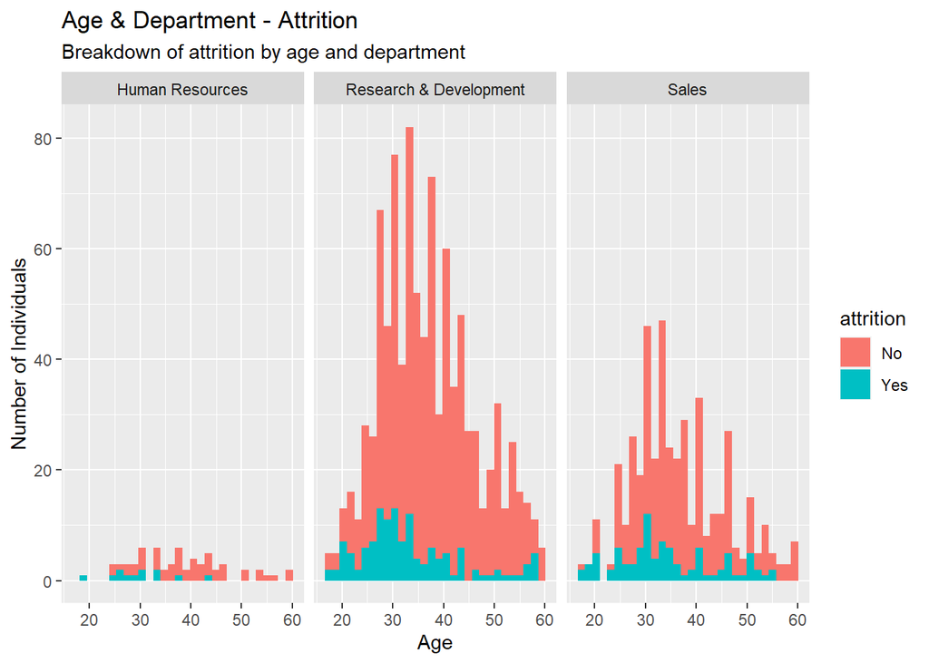

```r
kaggle_data %>%
  ggplot(aes(x = age, fill = attrition)) +
  geom_histogram() +
  facet_wrap(~department)+
  labs(
    title = "Age & Department - Attrition",
    subtitle = "Breakdown of attrition by age and department",
    y = "Number of Individuals",
    x = "Age"
  )
```

### Breakdown of distance from home by job role and attrition

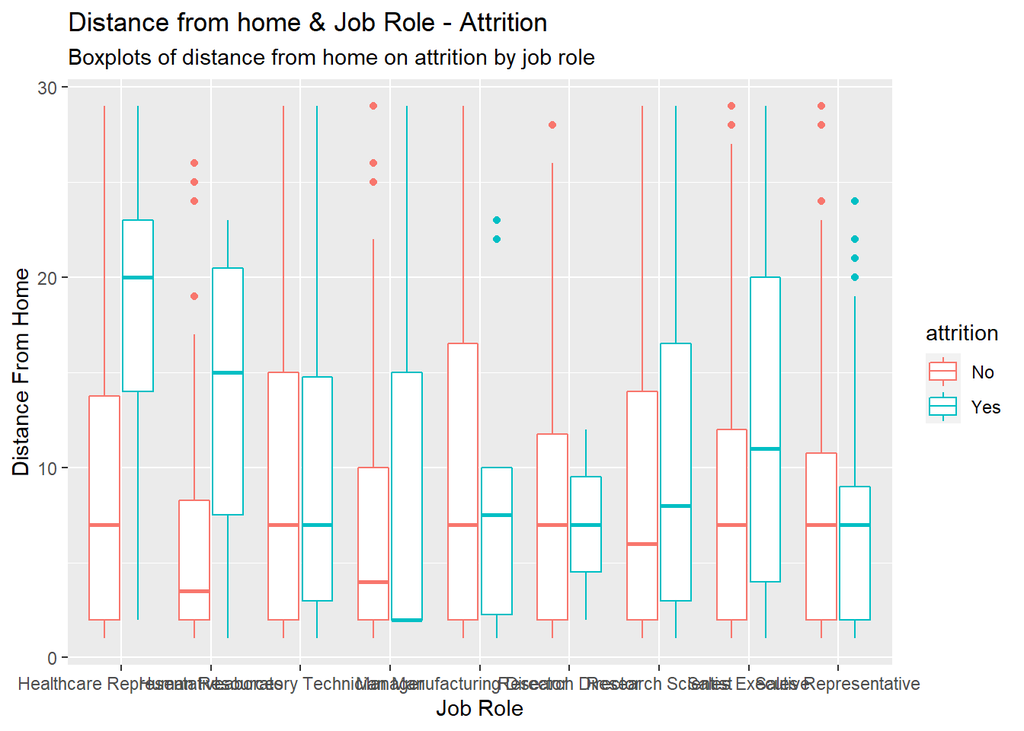

```r
kaggle_data %>%
  ggplot(aes(x = job_role, y = distance_from_home, color = attrition)) +
  geom_boxplot() +
  labs(
    title = "Distance from home & Job Role - Attrition",
    subtitle = "Boxplots of distance from home on attrition by job role",
    y = "Distance From Home",
    x = "Job Role"
  )
```

### Average Monthly income by education and attrition

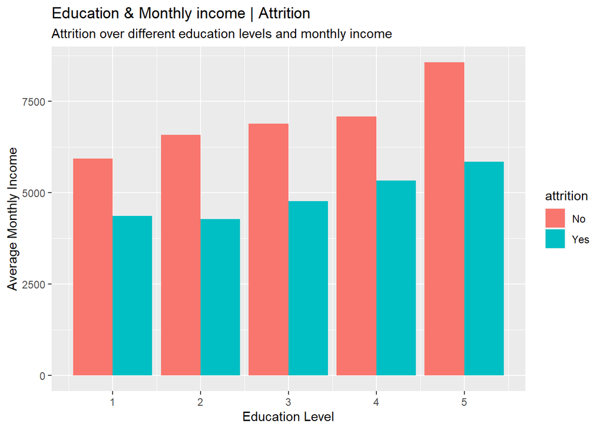

```r
kaggle_data %>%
  group_by(education, attrition) %>%
  summarise(avg_monthly_income = mean(monthly_income)) %>%
  ggplot(aes(x = education, y = avg_monthly_income, fill = attrition)) +
  geom_col(position = "dodge") +
  labs(
    title = "Education & Monthly income | Attrition",
    subtitle = "Attrition over different education levels and monthly income",
    x = "Education Level",
    y = "Average Monthly Income"

  )
```

### Job satisfaction and attrition by level and role

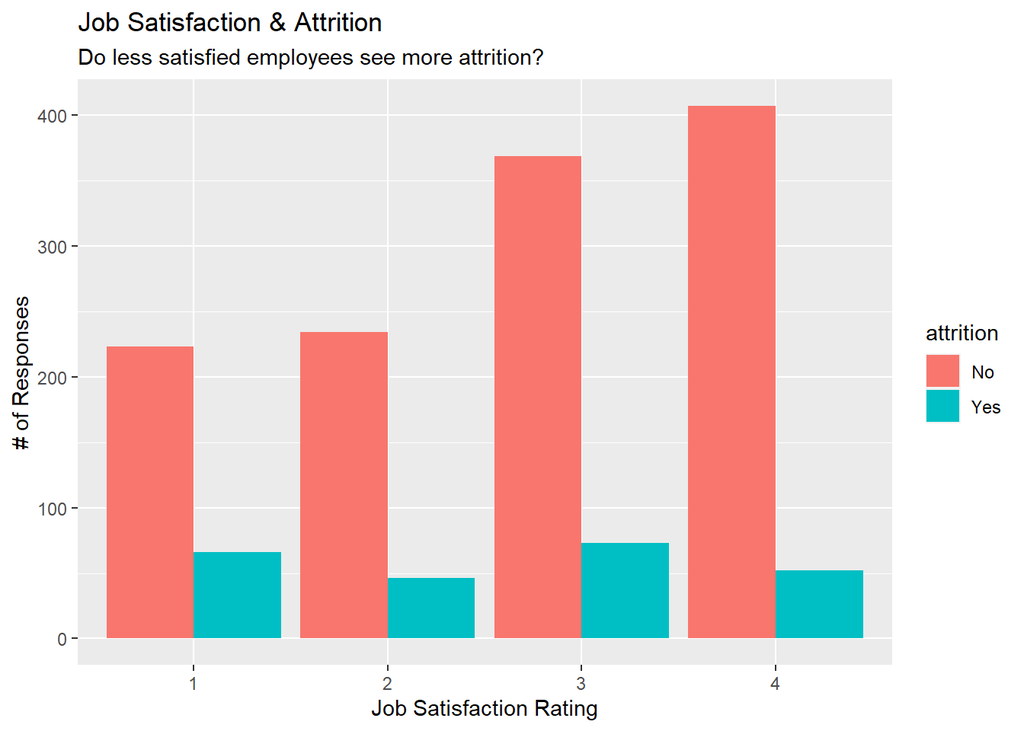

```r
kaggle_data %>%
  mutate(job_satisfaction = as.factor(job_satisfaction)) %>%
  group_by(job_satisfaction) %>%
  count(attrition) %>%
  ggplot(aes(x = job_satisfaction, y = n, fill = attrition)) +
  geom_col(position = "dodge") +
  labs(
    title = "Job Satisfaction & Attrition",
    subtitle = "Do less satisfied employees see more attrition?",
    x = "Job Satisfaction Rating",
    y = "# of Responses"
  )
```

### Gender Differences in attrition?

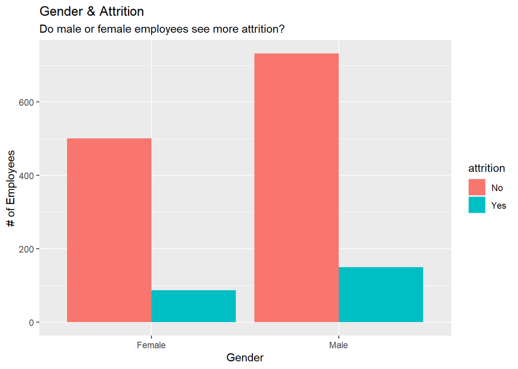

```r
kaggle_data %>%
  group_by(gender, attrition) %>%
  count(attrition) %>%
  ggplot(aes(x = gender, y = n, fill = attrition)) +
  geom_col(position = "dodge") +
  labs(
    title = "Gender & Attrition",
    subtitle = "Do male or female employees see more attrition?",
    x = "Gender",
    y = "# of Employees"
  )
```

### Theory-based approach to attrition (Burn-out)

- job_involvement (low)
- job_satisfaction (low)
- performance_rating (low)
- year_in_current_role (high)
- years_at_company (high)
- years_since_last_promotion (high)
- years_with_curr_manager (high)
- total_working_years (high)

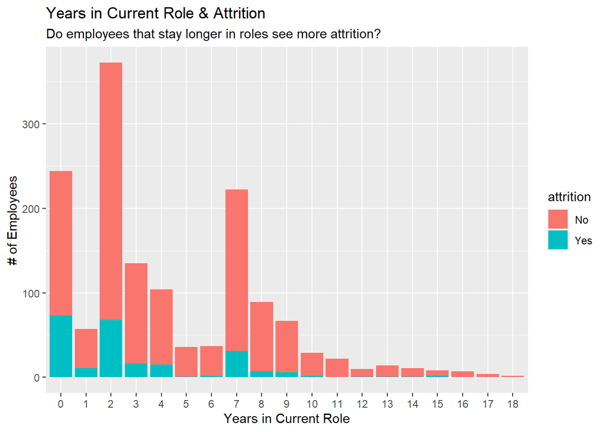

```r
kaggle_data %>%
  mutate(years_in_current_role = as.factor(years_in_current_role)) %>%
  group_by(years_in_current_role, attrition) %>%
  count(years_in_current_role) %>%
  ggplot(aes(x = years_in_current_role, y = n, fill = attrition)) +
  geom_col() +
  labs(
    title = "Years in Current Role & Attrition",
    subtitle = "Do employees that stay longer in roles see more attrition?",
    x = "Years in Current Role",
    y = "# of Employees"
  )
```

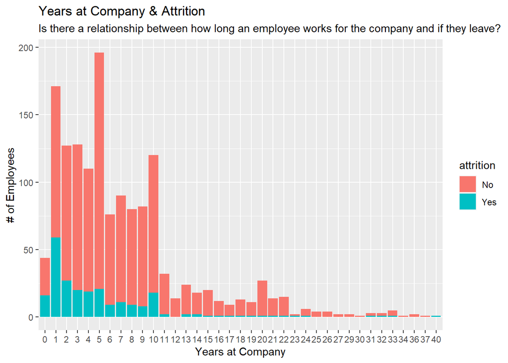

```r
kaggle_data %>%
  mutate(years_at_company = as.factor(years_at_company)) %>%
  group_by(years_at_company, attrition) %>%
  count(years_at_company) %>%
  ggplot(aes(x = years_at_company, y = n, fill = attrition)) +
  geom_col() +
  labs(
    title = "Years at Company & Attrition",
    subtitle = "Is there a relationship between how long an employee works for the company and if they leave?",
    x = "Years at Company",
    y = "# of Employees"
  )
```

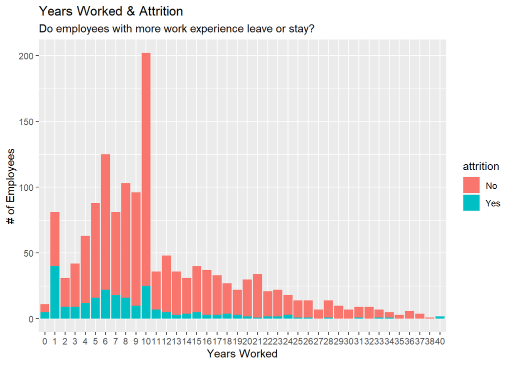

```r
kaggle_data %>%
  mutate(total_working_years = as.factor(total_working_years)) %>%
  group_by(total_working_years, attrition) %>%
  count(total_working_years) %>%
  ggplot(aes(x = total_working_years, y = n, fill = attrition)) +
  geom_col() +
  labs(
    title = "Years Worked & Attrition",
    subtitle = "Do employees with more work experience leave or stay?",
    x = "Years Worked",
    y = "# of Employees"
  )
```

# Feature Selection: 2 Birds - 1 Stone

Here I am going to be using a penalized logistic regression (basically a fancy logistic regression). Think of a normal logistic regression but we use *regularization*. Regularization is a way for us to increase our generalization of our models by adding penalties to the variables that shrinks the estimates of the coefficients.

This has two advantages:

1. It is a logistic regression
2. It selects features

I then can use those selected features for my other 2 models.

I’m recently becoming a fan of the `tidymodels` package that allows standardized uses of models. Lets start by using `recipes` and `rsamples` to make our dummy variables as well as scale our numeric variables.

```r
library(tidymodels, warn.conflicts = F)
library(glmnet,  warn.conflicts = F)
set.seed(123)

# Preprocesses our data
kaggle_pre_processed <-
  recipe(attrition ~ ., data = kaggle_data) %>%
  step_dummy(all_nominal(), -all_outcomes()) %>%
  step_rm(employee_number) %>%
  step_normalize(age, daily_rate, distance_from_home, hourly_rate, monthly_income, monthly_rate, num_companies_worked, percent_salary_hike, total_working_years, training_times_last_year, years_at_company, years_in_current_role, years_since_last_promotion, years_with_curr_manager) %>%
  prep() %>%
  bake(new_data = NULL)
```

Now we can split out data into a 70-30 split as well as create 10 folds

```r
# Index our split
data_split <- initial_split(kaggle_pre_processed, prop = .7)

kaggle_train <- training(data_split)
kaggle_test <- testing(data_split)

cf_kaggle_train <- vfold_cv(kaggle_pre_processed, v = 10)
```

## LASSO Logistic Regression

Lets start by creating our model. Now, penalty is a parameter that we have to estimate. We can do that by using a grid method. We can use the `tune()` function as a placeholder. We specify `mixture = 1` for LASSO.s

```r
# Specifying our model
glm_model <- logistic_reg(mode = "classification", mixture = 1, penalty = tune()) %>%
  set_mode("classification") %>%
  set_engine("glmnet")
```

### Tuning Lambda using a grid

Now we have our model we can go ahead and create something called a `workflow` that allows us to contain all our steps together (think of it as a bag to carry around all of our model objects like `glm_model` or a `recipe` object).

```r
glm_wf <-
  workflow() %>%
  add_model(glm_model) %>%
  add_formula(attrition ~ .)
```

Using the `grid_regular()` function, we can automatically make a bunch of potential lambda values.

```r
lambda_grid <- grid_regular(penalty(), levels = 50)
```

We can use the `tune_grid()` function to create a bunch of models using our `cf_kaggle_train` cross-validation set.

```r
glm_grid <- tune_grid(
  glm_wf,
  resamples = cf_kaggle_train,
  grid = lambda_grid
)
```

The `select_best()` function allows us to pull out the model that has the best metric we specify.

```r
best_roc_penalty <-
  glm_grid %>%
  select_best(metric = "roc_auc")
best_roc_penalty
```

```
## # A tibble: 1 x 2
##   penalty .config
##     <dbl> <chr>
## 1 0.00139 Preprocessor1_Model36
```

We can see the best lambda value we found is: 0.0013895

Woohoo!

Lets fit our model, this time we can make penalty our value:

```r
final_glm_model <-
  logistic_reg(mode = "classification", mixture = 1, penalty = best_roc_penalty$penalty) %>%
  set_mode("classification") %>%
  set_engine("glmnet") %>%
  fit(attrition ~ ., data = kaggle_train)
```

### Evalutation - Logistic Regression

Now we can use `predict()` to test our model on new data.

```r
glm_pred <- predict(final_glm_model, kaggle_test)

# Combine the predictions and actual values into a data.frame
glm_pred_table <-
  glm_pred %>%
  bind_cols(kaggle_test$attrition, .name_repair = ~ c("predicted", "actual"))

# Create a confusion matrix
glm_conf_matrix <- table(glm_pred_table)

# Calculate our accuracy
glm_results <- (glm_conf_matrix[1] + glm_conf_matrix[4]) / 441 # we have 441 rows in our test data

glm_results
```

```
## [1] 0.8888889
```

We get an accuracy of: 0.8888889.

### Extracting our parameters

Now we can extract the coefficients that are left with the following boot-leg code:

```r
final_glm_model_coefs <-
  final_glm_model %>%
  tidy() %>%
  filter(estimate != 0 & term != "(Intercept)")

variables <-
  final_glm_model_coefs %>%
  pull(term) %>%
  paste(collapse = " + ")
```

## Decision Tree

Lets look at using a decision tree!

Similar to our logistic regression, we have some parameters we need to estimate. (Shout-out to [Julia Silge’s blog post](https://juliasilge.com/blog/xgboost-tune-volleyball/) for the inspiration of this code)

```r
# Specify our model
xgb_model <- boost_tree(
  trees = 1000,
  tree_depth = tune(), min_n = tune(),
  loss_reduction = tune(), # first three: model complexity
  sample_size = tune(), mtry = tune(), # randomness
  learn_rate = tune(), # step size
) %>%
  set_engine("xgboost") %>%
  set_mode("classification")


# According to Julia Silge, we can use the latin Hypercube sampling method for our parameters
xgb_grid <- grid_latin_hypercube(
  tree_depth(),
  min_n(),
  loss_reduction(),
  sample_size = sample_prop(),
  finalize(mtry(), kaggle_train),
  learn_rate(),
  size = 30
)

# Creates a workflow with our LASSO selected variables
xgb_wf <-
  workflow() %>%
  add_model(xgb_model) %>%
  add_formula(attrition ~ age + daily_rate + distance_from_home + education + environment_satisfaction + hourly_rate + job_involvement + job_level + job_satisfaction + monthly_rate + num_companies_worked + percent_salary_hike + relationship_satisfaction + stock_option_level + total_working_years + training_times_last_year + work_life_balance + years_at_company + years_in_current_role + years_since_last_promotion + years_with_curr_manager + business_travel_Travel_Frequently + business_travel_Travel_Rarely + department_Sales + education_field_Marketing + education_field_Medical + education_field_Other + education_field_Technical.Degree + gender_Male + job_role_Human.Resources + job_role_Laboratory.Technician + job_role_Manager + job_role_Manufacturing.Director + job_role_Research.Director + job_role_Research.Scientist + job_role_Sales.Executive + job_role_Sales.Representative + marital_status_Married + marital_status_Single + over_time_Yes)

# Tunes the parameters
xgb_res <- tune_grid(
  xgb_wf,
  resamples = cf_kaggle_train,
  grid = xgb_grid,
  control = control_grid(save_pred = TRUE)
)
```

### Extracting our parameters

```r
xgb_accuracy <- select_best(xgb_res, "roc_auc")
xgb_accuracy
```

```
## # A tibble: 1 x 7
##    mtry min_n tree_depth learn_rate loss_reduction sample_size .config
##   <int> <int>      <int>      <dbl>          <dbl>       <dbl> <chr>
## 1    46    15         11     0.0448          0.134       0.649 Preprocessor1_Mo~
```

### Evaluation - Decision Tree

Putting it all together:

```r
# A shortcut to putting the best values into our model
final_xgb <- finalize_workflow(
  xgb_wf,
  xgb_accuracy
)

# Fits the model to our training data
final_res <- last_fit(final_xgb, data_split)

# Display the accuracy
xgb_results <- collect_metrics(final_res)
xgb_results
```

```
## # A tibble: 2 x 4
##   .metric  .estimator .estimate .config
##   <chr>    <chr>          <dbl> <chr>
## 1 accuracy binary         0.866 Preprocessor1_Model1
## 2 roc_auc  binary         0.796 Preprocessor1_Model1
```

## SVM

```r
# Specify our model and our tuning parameters
svm_model <-
  svm_rbf(cost = tune(), rbf_sigma = tune()) %>%
  set_mode("classification") %>%
  set_engine("kernlab")

# Creates a workflow with our LASSO selected variables
svm_wf <-
  workflow() %>%
  add_model(svm_model) %>%
  add_formula(attrition ~ age + daily_rate + distance_from_home + education + environment_satisfaction + hourly_rate + job_involvement + job_level + job_satisfaction + monthly_rate + num_companies_worked + percent_salary_hike + relationship_satisfaction + stock_option_level + total_working_years + training_times_last_year + work_life_balance + years_at_company + years_in_current_role + years_since_last_promotion + years_with_curr_manager + business_travel_Travel_Frequently + business_travel_Travel_Rarely + department_Sales + education_field_Marketing + education_field_Medical + education_field_Other + education_field_Technical.Degree + gender_Male + job_role_Human.Resources + job_role_Laboratory.Technician + job_role_Manager + job_role_Manufacturing.Director + job_role_Research.Director + job_role_Research.Scientist + job_role_Sales.Executive + job_role_Sales.Representative + marital_status_Married + marital_status_Single + over_time_Yes)

# Tunes the parameters
formula_res <-
  tune_grid(
    svm_wf,
    resamples = cf_kaggle_train
  )
```

### Extracting our parameters

```r
svm_best_acc <- select_best(formula_res, "roc_auc")
svm_best_acc
```

```
## # A tibble: 1 x 3
##     cost rbf_sigma .config
##    <dbl>     <dbl> <chr>
## 1 0.0957    0.0177 Preprocessor1_Model06
```

### Evaluation - SVM

```r
final_svm <- finalize_workflow(
  svm_wf,
  svm_best_acc
)

svm_results <-
  last_fit(final_svm, data_split) %>%
  collect_metrics()

svm_results
```

```
## # A tibble: 2 x 4
##   .metric  .estimator .estimate .config
##   <chr>    <chr>          <dbl> <chr>
## 1 accuracy binary         0.830 Preprocessor1_Model1
## 2 roc_auc  binary         0.796 Preprocessor1_Model1
```

# Summary/Analysis

[output not shown]

As we can see from the table, our Logistic Regression seemed to perform the best in terms of accuracy.

# References

https://juliasilge.com/blog/xgboost-tune-volleyball/

https://www.tidymodels.org/start/tuning/

https://compgenomr.github.io/book/logistic-regression-and-regularization.html